# 1-selecao_prep

- https://towardsdatascience.com/data-preprocessing-and-model-comparison-techniques-you-must-know-1347edb319e7
- https://betterprogramming.pub/data-preprocessing-for-machine-learning-3822ace03ae6
- https://machinelearningmastery.com/perform-feature-selection-machine-learning-data-weka/
- https://medium.com/swlh/data-preprocessing-and-data-modeling-for-kaggle-house-price-prediction-data-in-python-c04055ded258

```python
!kinit -V -kt bigsa027_prd.keytab bigsa027@PRODHWBB.COM.BR
```

```
Using default cache: /tmp/krb5cc_1000
Using principal: bigsa027@PRODHWBB.COM.BR
Using keytab: bigsa027_prd.keytab
kinit: Cannot find KDC for realm "PRODHWBB.COM.BR" while getting initial credentials
```

```python
!scp -p 1319900@pxl1big00024.dispositivos.bb.com.br:/etc/security/keytabs/bigsa027.keytab ./
```

```
The authenticity of host 'pxl1big00024.dispositivos.bb.com.br (172.20.104.41)' can't be established.
RSA key fingerprint is SHA256:bFhvklLamrGPoyEyiVYQrlDZrVoUIanD5vVXCjDlO9g.
RSA key fingerprint is MD5:3b:0d:38:a7:dd:6e:ad:a8:cf:0e:76:82:ae:f4:6d:ba.
Are you sure you want to continue connecting (yes/no)?
```

```python
%load_ext sparkmagic.magics
%spark cleanup
```

```python
%spark add -s sessao_sbx_ -l python -u http://pxl1big00166.dispositivos.bb.com.br:8088 -t Kerberos -a bigsa027 -o OUTPUT
```

```
An error was encountered:
Invalid status code '404' from http://pxl1big00166.dispositivos.bb.com.br:8088/sessions with error payload:
```

```python
#!pip install seaborn --user
#!pip install matplotlib --user
#!pip install sklearn --user
```

```python
## LIBS PARA MANIPULAÇÃO DOS DADOS
import pandas as pd
import numpy as np
import matplotlib.pyplot as plt
import seaborn as sns
from sklearn import preprocessing
from collections import Counter
#import joblib
#%matplotlib inline

import warnings
warnings.filterwarnings('ignore')
pd.set_option('display.max_columns', 500)

from sklearn.preprocessing import StandardScaler,MinMaxScaler
from sklearn.preprocessing import OneHotEncoder, LabelEncoder
import pprint

import csv

def get_limits_quantile(data):
    q1 = data.quantile(.25)
    q3 = data.quantile(.75)

    sup = q3 + 1.5 * (q3-q1)
    inf = q1 - 1.5 * (q3-q1)

    return inf, sup
print('OK')
```

```
OK
```

```python
from util import transf_dados
```

```
OK
```

## Preparação dos dados

```python
dados = pd.read_csv('amostra_pme.csv',dtype={'CD_CLI_PJ':str})#,encoding='latin-1')

## criando base de dados para fazer validacão do algoritmo
validacao = dados.sample(10000,random_state=123)
validacao.to_csv('validacao.csv',index = False,quoting=csv.QUOTE_NONNUMERIC)

dados = dados.drop(validacao.index)#.sample(30000,random_state = 123)
dados.reset_index(drop = True, inplace = True)
dados.shape
```

```
(190000, 26)
```

```python
## LIMPANDO COLUNAS TEXTUAIS
colunas_categoricas = ["NM_CLI","SG_UF","TX_CTGR_CHURN","FXA_LTV","RFV","CD_SCAO","TX_CLSC_NVL"]#,"LTV","QT_DD","VL_FLX_VNCT","VL_VNCT",'VL_FATM']
dados[colunas_categoricas] = dados[colunas_categoricas].apply(lambda x: x.str.replace('\r','').str.strip(), axis = 1)
```

```python
## CONVERTENDO COLUNAS QUANTITATIVAS PARA FLOAT
colunas_numericas = ["QT_SCO","MED_PROPENSAO_SCO","MED_IDD_SCO","IN_PPL_BB","IN_TRNS_TITD","PC_CHURN","LTV","QT_DD","VL_FLX_VNCT","VL_VNCT",'VL_FATM']
dados[colunas_numericas] = ( dados[colunas_numericas].apply(lambda x: x.replace(",",".",regex=True).astype(float),axis = 1) )
```

```python
dados.replace("-8",np.NaN,inplace = True)
dados.replace(-8,np.NaN,inplace = True)
```

```python
print("Proporção de valores NA nas colunas")
(dados.isnull().sum() / len(dados) * 100).sort_values(ascending = False).round(3)

#as duas primeiras sao removidas
```

```
Proporção de valores NA nas colunas
```

```
MED_PROPENSAO_SCO    41.732
CD_GER_SCO           10.015
QT_SCO                9.998
MED_IDD_SCO           9.998
RFV                   5.615
PC_CHURN              5.029
FXA_LTV               5.029
LTV                   5.029
TX_CTGR_CHURN         5.029
TX_CLSC_NVL           0.988
CD_SCAO               0.988
NM_CLI                0.001
SG_UF                 0.001
IN_TRNS_TITD          0.000
CD_TIP_PSS            0.000
IN_PPL_BB             0.000
VL_FATM               0.000
IN_RST                0.000
CD_IN_EDV_FORA        0.000
VL_VNCT               0.000
NM_SGM_BB             0.000
QT_DD                 0.000
TX_MED_PDRD           0.000
CD_OPC_FSC            0.000
VL_FLX_VNCT           0.000
CD_CLI_PJ             0.000
dtype: float64
```

```python
dados.shape
```

```
(190000, 26)
```

```python
# dados[['MED_PROPENSAO_SCO','MED_IDD_SCO']].hist(figsize=(10,7))
```

### **Imputacão valores NA**

```python
## ARMAZENAR AS MÉDIAS UTILIZADAS PARA CORREÇÃO DOS NAs
 # A SEREM UTILIZADAS NA VALIDAÇÃO/PRODUÇÃO
medias = {}
dados[colunas_numericas].apply(lambda x: medias.update({x.name: x.median() }),axis=0)
medias
```

```
{'QT_SCO': 1.0,
 'MED_PROPENSAO_SCO': 0.49,
 'MED_IDD_SCO': 46.0,
 'IN_PPL_BB': 0.0,
 'IN_TRNS_TITD': 0.0,
 'PC_CHURN': 0.1006672469,
 'LTV': 4362.7339474,
 'QT_DD': 2.0,
 'VL_FLX_VNCT': 3998.84,
 'VL_VNCT': 0.0,
 'VL_FATM': 269150.91000000003}
```

```python
## SALVANDO MÉDIAS EM JSON
import json
json.dump(medias,open('modelos/medias_treinamento.json','w'))
```

#todas as colunas numericas foram imputados pela mediana #dados.replace(-8,np.NaN,inplace = True) #dados.dropna(subset=['CD_GER_SCO'],inplace = True) #dados.dropna(subset=['PC_CHURN'],inplace = True) #dados.dropna(subset=['RFV'],inplace = True) #dados.dropna(subset=['TX_CLSC_NVL'],inplace = True) #dados.dropna(subset=['TX_CLSC_NVL'],inplace = True) ## imputação(mediana) definida pela área de negócio medias.update({'PC_CHURN': dados.PC_CHURN.median() }) #print('PC_CHURN',dados.PC_CHURN.median()) #dados.PC_CHURN.fillna(dados.PC_CHURN.median(),inplace = True) medias.update({'LTV': dados.LTV.median() }) medias.update({'MED_PROPENSAO_SCO': dados.MED_PROPENSAO_SCO.median() }) #print('LTV',dados.LTV.median()) #dados.LTV.fillna(dados.LTV.median(),inplace = True) #print(dados[['MED_PROPENSAO_SCO']].median()) #dados[['MED_PROPENSAO_SCO']] = dados[['MED_PROPENSAO_SCO']].fillna(dados[['MED_PROPENSAO_SCO']].median()) """ dados_clean.loc[(dados_clean.IN_TRNS_TITD == 1) & (dados_clean.MED_PROPENSAO_SCO.isnull()),'MED_PROPENSAO_SCO'] = dados_clean.query('IN_TRNS_TITD == 1')['MED_PROPENSAO_SCO'].median() dados_clean.loc[(dados_clean.IN_TRNS_TITD == 0) & (dados_clean.MED_PROPENSAO_SCO.isnull()),'MED_PROPENSAO_SCO'] = dados_clean.query('IN_TRNS_TITD == 0')['MED_PROPENSAO_SCO'].median() """ #dados.dropna(subset=['FXA_LTV'],inplace = True) dados['FXA_LTV'].fillna(0,inplace = True) dados.RFV = dados.RFV.fillna('N/I')

```python
for c in ['PC_CHURN','LTV','MED_PROPENSAO_SCO']:
    print(c)
    dados[c].fillna(medias[c],inplace = True)

dados['FXA_LTV'].fillna(0,inplace = True)
dados.RFV = dados.RFV.fillna('N/I')
```

```
PC_CHURN
LTV
MED_PROPENSAO_SCO
```

```python
## colunas irrelevantes para o modelo (será mantipo o CNPJ para depois fazer o merge do resultado)
dados = dados.drop(columns = ['CD_TIP_PSS','QT_DD','CD_SCAO','TX_CLSC_NVL'])
```

```python
## excluindo valores "noisy" da média da idade, definido pela área de negócio
## tratando outliers
dados = dados.query('MED_IDD_SCO <= 100 and MED_IDD_SCO >= 18')

## excluindo valores "noisy" do valor de faturamento, definido pela área de negócio
#dados = dados.query("VL_FATM <= 5000000")
```

```python
dados.reset_index(drop=True,inplace=True)
dados_clean = dados.copy()

dados_clean.shape
```

```
(170971, 22)
```

## corrigindo VL_VNCT quando for maior que VL_FLX_VNCT. Definido pela área de negócio # dados_clean = dados_clean.query("VL_VNCT <= VL_FLX_VNCT") #dados_clean.VL_VNCT = dados_clean.apply(lambda x: x['VL_VNCT'] if x['VL_VNCT'] > x['VL_FLX_VNCT'] else x['VL_VNCT'], axis=1) # (dados.shape[0] - dados_clean.shape[0]) / dados_clean.shape[0] * 100, dados_clean.shape #dados_clean.query('IN_TRNS_TITD == 1')['MED_PROPENSAO_SCO'].median() dados_clean.query('IN_TRNS_TITD == 1')['MED_PROPENSAO_SCO'].isnull().sum(), dados_clean.query('IN_TRNS_TITD == 1')['MED_PROPENSAO_SCO'].isnull().sum() dados_clean.query('IN_TRNS_TITD == 0')['MED_PROPENSAO_SCO'] dados_clean.MED_PROPENSAO_SCO.isnull().sum()

## imputação(mediana do grupo) definida pela área de negócio mediana_nicho = dados_clean.query("NM_SGM_BB == '4 - Nicho Empreendedor' and VL_FATM < 120000").groupby('NM_SGM_BB').VL_FATM.median().values[0] dados_clean.query("NM_SGM_BB == '4 - Nicho Empreendedor' and VL_FATM < 120000")['VL_FATM'] = mediana_empreend for c in dados_clean.NM_SGM_BB.unique(): mediana_nicho = dados_clean.query("NM_SGM_BB == '{}' and VL_FATM < 120000".format(c)).groupby('NM_SGM_BB').VL_FATM.median().values#[0] print(c, mediana_nicho, mediana_nicho.size) sns.boxplot(x = 'IN_TRNS_TITD', y = 'VL_FATM', data = dados_clean) #.VL_FATM.hist()plt.figure(figsize = (15,5)) sns.boxplot(x = 'NM_SGM_BB', y = 'VL_FATM', data = dados_clean) #.VL_FATM.hist()

### **------------------------------------------------------**

### **NÃO EXCLUIR CÓDIGO ABAIXO**

## imputação(mediana do grupo) definida pela área de negócio 4 - Nicho Empreendedor for c in dados_clean.NM_SGM_BB.unique(): print(c) mediana_nicho = dados_clean.query("NM_SGM_BB == '{}' and VL_FATM < 120000".format(c)).groupby('NM_SGM_BB').VL_FATM.median().values#[0] if mediana_nicho.size > 0: dados_clean.query("NM_SGM_BB == '{}' and VL_FATM < 120000")['VL_FATM'] = mediana_nicho[0]

### **------------------------------------------------------**

```python
# proporcao VL_VNCT / VL_FLX_VNCT, definida pela área de negócio
## Nao vai ser utilizada - verificar se ela e usada
dados_clean['PROP_VL_VNCT'] = dados_clean.apply(lambda x: x['VL_VNCT'] / x['VL_FLX_VNCT'] if x['VL_FLX_VNCT'] > 1 else x['VL_FLX_VNCT'] , axis = 1) #[['MED_PROPENSAO_SCO']].fillna(dados[['MED_PROPENSAO_SCO']].median())
```

**CATEGORIZACAO DO CHURN**

- sem propensao(0) - < 0.1
- baixa(1) - 0.10-0.20
- media(2) - 0.20-0.30
- alta(3) - > 0.30

```python
#dados_clean['PC_CHURN']
## nao e utilizada no modelo
dados_clean['TX_CTGR_CHURN'] = pd.cut(dados_clean['PC_CHURN'], bins=[0, .1, .2, .3, 1],labels=[0,1,2,3]).astype(int)

dados_clean.TX_CTGR_CHURN.unique(), dados_clean.TX_CTGR_CHURN.value_counts()
```

```
(array([0, 1, 2, 3]),
 0    82570
 1    44350
 2    27470
 3    16581
 Name: TX_CTGR_CHURN, dtype: int64)
```

## Categorização do PROPENSAO SCO

```python
#dados_clean.MED_PROPENSAO_SCO.hist()
```

- <= .41: sem propensao
- > .41-0.50: baixa
- > .50-.60: media
- > .60: alta

```python
tx_propensao = []
## nao utilizada no modelo
for v in dados_clean['MED_PROPENSAO_SCO']:
    if v <= .41:
        tx_propensao.append(1)
    elif v > .41 and v <= .5:
        tx_propensao.append(2)
    elif v > .5 and v <= .6:
        tx_propensao.append(3)
    elif v > .6:
        tx_propensao.append(4)
    else:
        tx_propensao.append(0)
dados_clean['MED_PROPENSAO_SCO_TXT'] = tx_propensao

dados_clean['MED_PROPENSAO_SCO_TXT'].value_counts()
```

```
2    80654
1    43904
4    34506
3    11907
Name: MED_PROPENSAO_SCO_TXT, dtype: int64
```

## Categorização do faturamento VL_FATM

- categorização definida pela área de negócio (José Murta)

```python
## nao utilizada no modelo
tx_fatm = []
for v in dados_clean['VL_FATM']:
    if v <= 360000:
        tx_fatm.append(1)
    elif v > 360000 and v <= 1000000:
        tx_fatm.append(2)
    elif v > 1000000 and v <= 5000000:
        tx_fatm.append(3)
    elif v > 5000000 and v <= 25000000:
        tx_fatm.append(4)
    elif v > 25000000:
        tx_fatm.append(5)
    else:
        tx_fatm.append(0)

dados_clean['VL_FATM_TXT'] = tx_fatm

dados_clean['VL_FATM_TXT'].value_counts()
```

```
1    89266
3    43017
2    29638
4     7578
5     1472
Name: VL_FATM_TXT, dtype: int64
```

## Categorização do VL_FLX_VNCT

tx_vl_flx = [] for v in dados_clean['VL_FLX_VNCT']: if v <= 10596: tx_vl_flx.append(1) elif v > 10596 and v <= 33352.0: tx_vl_flx.append(2) elif v > 33352.0 and v <= 100000.0: tx_vl_flx.append(3) elif v > 100000.0 and v <= 302816.0: tx_vl_flx.append(4) elif v > 302816.0: tx_vl_flx.append(5) dados_clean['VL_FLX_VNCT_TXT'] = tx_vl_flx dados_clean['VL_FLX_VNCT_TXT'].value_counts()

## Categorização do LTV

```python
LTV_flx = []
## nao utilizada no modelo
for v in dados_clean['LTV']:
    if v < 0:
        LTV_flx.append(1)
    elif v > 0 and v <= 3378:
        LTV_flx.append(2)
    elif v > 3378 and v <= 11671.0:
        LTV_flx.append(3)
    elif v > 11671.0 and v <= 135896.0:
        LTV_flx.append(4)
    elif v > 135896.0 :
        LTV_flx.append(5)

dados_clean['LTV_TXT'] = LTV_flx
```

dados_clean.VL_FLX_VNCT.hist()dados_clean.query("LTV > 0").boxplot('LTV')#LTV, VL_FLX_VNCT dados_clean.LTV.hist()

### **CRIANDO VARIÁVEL CLASSE**

A regra foi decidida pela área de negócio.

- Opção 1: se possui endividamento total maior que no BB
- Opção 2: transferência de mesma tit. OU endividamento fora maior que no banco

```python
dados_clean['CLASSE'] = dados_clean.apply(lambda x: 1 if (x['VL_FLX_VNCT'] > x['VL_VNCT']) | (x['IN_TRNS_TITD'] == 1) else 0,axis = 1) # | (x['IN_TRNS_TITD'] == 1)
```

```python
# dados_clean.describe().round(2)
print("Proporção de valores NA nas colunas")
dados_clean.isnull().sum() / len(dados) * 100
```

```
Proporção de valores NA nas colunas
```

```
CD_CLI_PJ                0.000000
NM_CLI                   0.000000
SG_UF                    0.000585
QT_SCO                   0.000000
MED_PROPENSAO_SCO        0.000000
MED_IDD_SCO              0.000000
CD_GER_SCO               0.000000
IN_PPL_BB                0.000000
IN_TRNS_TITD             0.000000
IN_RST                   0.000000
CD_IN_EDV_FORA           0.000000
PC_CHURN                 0.000000
TX_CTGR_CHURN            0.000000
LTV                      0.000000
FXA_LTV                  0.000000
RFV                      0.000000
NM_SGM_BB                0.000000
TX_MED_PDRD              0.000000
CD_OPC_FSC               0.000000
VL_FLX_VNCT              0.000000
VL_VNCT                  0.000000
VL_FATM                  0.000000
PROP_VL_VNCT             0.000000
MED_PROPENSAO_SCO_TXT    0.000000
VL_FATM_TXT              0.000000
LTV_TXT                  0.000000
CLASSE                   0.000000
dtype: float64
```

```python
dados_clean.reset_index(drop=True,inplace=True)
dados_clean.to_csv('dados_clean.csv',index = False)
```

# **Análise Exploratória**

```python
dados_clean = pd.read_csv('dados_clean.csv')
#dados_clean = dados_clean.loc[:,[True if '_LOG' not in c else False for c in dados_clean.columns ]]
```

```python
colunas_numericas = dados_clean.columns[dados_clean.columns != 'O']
```

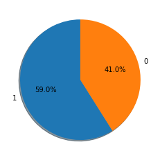

```python
counts = dados_clean.CLASSE.value_counts()
plt.pie(counts.values,labels = counts.index,autopct='%1.1f%%',shadow=True, startangle=90)
plt.show()
```

```python
#sns.pairplot(dados_clean,hue="CLASSE") # [['VL_FLX_VNCT','VL_VNCT','VL_FATM','IN_TRNS_TITD','PROP_VL_VNCT']]
```

**Análises pairplot:**

```python
#[ np.log(i) if np.isfinite(np.log(i)) else 0 for i in [5,55,-5,-55]]

#dados_clean.VL_FATM.apply(lambda x: np.log(x) if np.isfinite(np.log(x)) else 0 )
```

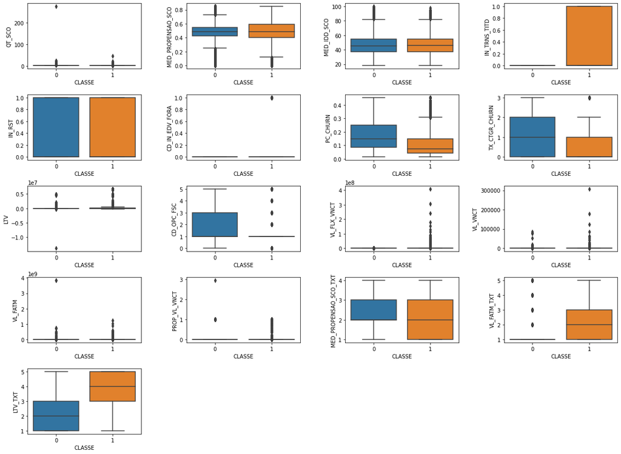

```python
i = 1
fig = plt.figure(figsize = (20,15))
fig.subplots_adjust(hspace=0.4, wspace=0.4)
for j,c in enumerate(dados_clean.columns): #['VL_FLX_VNCT','VL_VNCT','VL_FATM','IN_TRNS_TITD']):
    #print(c)
    if dados_clean[c].dtypes != 'O' and c not in ['CD_CLI_PJ','CD_TIP_PSS','IN_PPL_BB','CLASSE']:
        #print(i,c)
        ax = fig.add_subplot(5, 4, i)
        sns.boxplot(y = c,data = dados_clean,ax = ax, x = 'CLASSE')
        i +=  1
```

**Análises boxplot:**

- RESULTADO DAS ANÁLISES (24/04)
  - Após tratar os outlier (correção e exclusão) os dados estão mais ajutados, havendo uma diferença entre as 2 classes (intervalo de confiança)
  - aparentemente as melhores variáveis são: MED_PROPENSAO, PC_CHURN, VL_FATM.
- RESULTADO DAS ANÁLISES (19-23/04)
  - Colunas QT_SCO, MED_IDD dados com comportamentos iguais para as duas saídas (interseção intervalo de confiança)
  - muitos outliers: Tratar os outlier: replace, excluir?
  - variaveis com comportamentos semelhantes para as duas classes da target

## NORMALIZANDO OS DADOS COM LOG

for j,c in enumerate(dados_clean.columns): if dados_clean[c].dtypes != 'O' and c not in ['CD_CLI_PJ','CD_TIP_PSS','IN_PPL_BB','IN_TRNS_TITD']: dados_clean[c+'_LOG'] = dados_clean[c].apply(lambda x: np.log(x) if np.isfinite(np.log(x)) else 0 ) dados_clean.head()dados_clean[['QT_SCO','MED_IDD_SCO','PC_CHURN','LTV','VL_FLX_VNCT','VL_FATM','PROP_VL_VNCT']].describe().round(3)

## TRATANDO OUTROS OUTLIER UTILIZANDO LIMITE INFERIOR E SUPERIOR

medias_limites = {} classe = False ## flag pra indicar se vai fazer correcao por classe for j,c in enumerate(['QT_SCO','MED_IDD_SCO','PC_CHURN','LTV','VL_FLX_VNCT','VL_FATM','PROP_VL_VNCT']): if dados_clean[c].dtypes != 'O' and c not in ['CD_CLI_PJ','CD_TIP_PSS','IN_PPL_BB','IN_TRNS_TITD','TX_CTGR_CHURN', 'CD_GER_SCO','IN_RST','CD_OPC_FSC']: print(c)#, limites_0,limites_1) media = dados_clean[c].median() ## mediana GERAL medias_limites.update({c:{'media':media}}) if classe: limites_0 = get_limits_quantile(dados_clean.query('IN_TRNS_TITD==0')[c]) limites_1 = get_limits_quantile(dados_clean.query('IN_TRNS_TITD==1')[c]) media_0 = dados_clean.query('IN_TRNS_TITD==0')[c].median() ## mediana para a classe 0 media_1 = dados_clean.query('IN_TRNS_TITD==1')[c].median() dados_clean.loc[(dados_clean.IN_TRNS_TITD == 0) & (dados_clean[c] < limites_0[0]),c] = media_0 dados_clean.loc[(dados_clean.IN_TRNS_TITD == 0) & (dados_clean[c] > limites_0[1]),c] = media_0 dados_clean.loc[(dados_clean.IN_TRNS_TITD == 1) & (dados_clean[c] < limites_1[0]),c] = media_1 dados_clean.loc[(dados_clean.IN_TRNS_TITD == 1) & (dados_clean[c] > limites_1[1]),c] = media_1 else: limites = get_limits_quantile(dados_clean[c]) medias_limites.update({c:{'media':media,'inf':limites[0],'sup':limites[1]}}) media = dados_clean[c].median() ## mediana dados_clean.loc[(dados_clean[c] < limites[0]) | (dados_clean[c] > limites[1]),c] = media medias_limites

```python
dados_clean[['QT_SCO','MED_IDD_SCO','PC_CHURN','LTV','VL_FLX_VNCT','VL_FATM','PROP_VL_VNCT']].describe().round(3)
```

|  | QT_SCO | MED_IDD_SCO | PC_CHURN | LTV | VL_FLX_VNCT | VL_FATM | PROP_VL_VNCT |
| --- | --- | --- | --- | --- | --- | --- | --- |
| count | 170971.000 | 170971.000 | 170971.000 | 1.709710e+05 | 1.709710e+05 | 1.709710e+05 | 170971.000 |
| mean | 1.349 | 46.470 | 0.140 | 1.017142e+05 | 2.060316e+05 | 1.742898e+06 | 0.001 |
| std | 0.937 | 12.576 | 0.101 | 4.267243e+05 | 1.951875e+06 | 1.635983e+07 | 0.028 |
| min | 1.000 | 18.000 | 0.014 | -1.379775e+07 | 0.000000e+00 | 0.000000e+00 | 0.000 |
| 25% | 1.000 | 37.000 | 0.063 | -1.948130e+02 | 0.000000e+00 | 6.677000e+04 | 0.000 |
| 50% | 1.000 | 46.000 | 0.101 | 4.362734e+03 | 5.048250e+03 | 3.147581e+05 | 0.000 |
| 75% | 2.000 | 55.000 | 0.203 | 3.310195e+04 | 8.137271e+04 | 1.217297e+06 | 0.000 |
| max | 276.000 | 100.000 | 0.454 | 6.747806e+06 | 4.085128e+08 | 3.846147e+09 | 2.955 |

## Análise estatística (variação) das duas classes

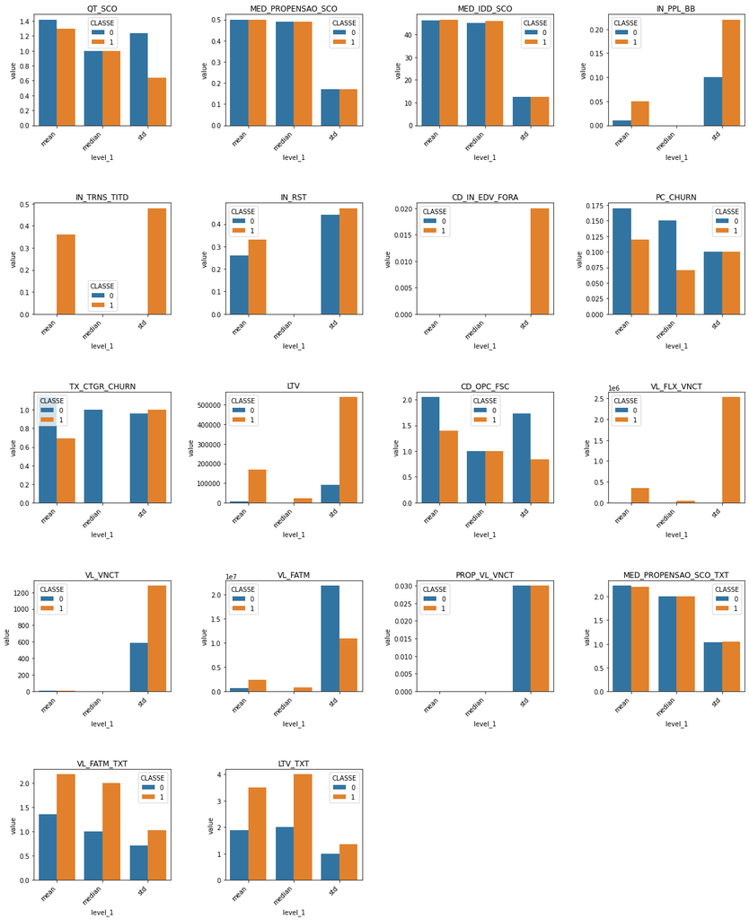

```python
pd.set_option('display.max_rows', None)
df = dados_clean.drop(columns = ['CD_CLI_PJ']).groupby('CLASSE').agg(['mean','median','std']).T.round(2)
estats_df = df.reset_index().melt(['level_0','level_1'])

i = 1
fig = plt.figure(figsize = (20,25))
fig.subplots_adjust(hspace=0.7, wspace=0.4)
for c in estats_df.level_0.unique()[:]:
    d =  estats_df.query("level_0 == '{}'".format(c))
    #print(i,c)
    ax = fig.add_subplot(5, 4, i)
    g = sns.barplot(x = 'level_1', y = 'value', data = d,hue = 'CLASSE')
    plt.xticks(rotation=45,ha='right')
    plt.title(c)
    i +=  1

#sns.barplot(x = 'level_0', y = 'value', data = estats_df,hue = 'IN_TRNS_TITD')
#plt.xticks(rotation=45,ha='right')
plt.show()
```

### **Corrigindo colunas com assimetria muito grande, com LOG**

dados_clean.columns## ANLISANDO ASSIMETRIA DAS COLUNAS dados_clean[colunas_numericas].skew().sort_values(ascending = False)colunas_log = ['VL_VNCT','PROP_VL_VNCT','VL_FATM','VL_FLX_VNCT','QT_SCO','CD_OPC_FSC'] # ,'LTV' dados_clean[[i+'_LOG' for i in colunas_log]] = dados_clean[colunas_log].apply(lambda x: np.log(x + 1)) np.isfinite(np.log(1)) dados_clean['LTV_LOG'] = dados_clean.LTV.apply(lambda x: np.log(x) if np.isfinite(np.log(x)) else 0 )# EXCLUINDO OUTLIER COM BASE NAS ANÁLISES REALIZADAS(GRÁFICOS) dados_clean = dados_clean.query("QT_SCO <= 10") dados_clean = dados_clean.query("VL_FLX_VNCT < 5000000") dados_clean = dados_clean.query("VL_VNCT < 1000000") #dados_clean = dados_clean.query("VL_FATM > 1 and VL_FATM < 10000000") dados_clean = dados_clean.query("PROP_VL_VNCT < 15") dados_clean.reset_index(drop=True, inplace=True)

i = 1 fig = plt.figure(figsize = (20,25)) fig.subplots_adjust(hspace=0.7, wspace=0.4) for c in ["CD_GER_SCO","FXA_LTV","RFV","NM_SGM_BB","SG_UF"]: #print(i,c) ax = fig.add_subplot(5, 3, i) g = sns.countplot(data = dados_clean,ax = ax, x = c)#,color='blue') plt.xticks(rotation=45,ha='right') i += 1

**Análises graficos bar(categoricas):**

## Correlação de Pearson

plt.figure(figsize = (15,12)) sns.heatmap(dados_clean.drop(columns=['CD_CLI_PJ']).corr(), annot=True,linewidths=.3) plt.show()

**Análises correlação:**

## Correlação de Spermman

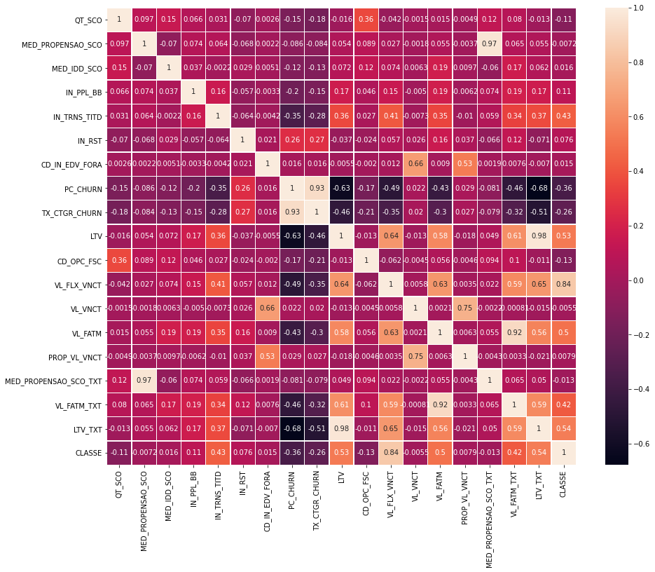

```python
plt.figure(figsize = (15,12))
#c = list(dados_clean.columns[ [ '_LOG' in i for i in dados_clean.columns] ])
#c.extend(['IN_TRNS_TITD'])

sns.heatmap(dados_clean.drop(columns=['CD_CLI_PJ']).corr('spearman'), annot=True,linewidths=.3)
plt.show()
```

## Correlação de Kendall

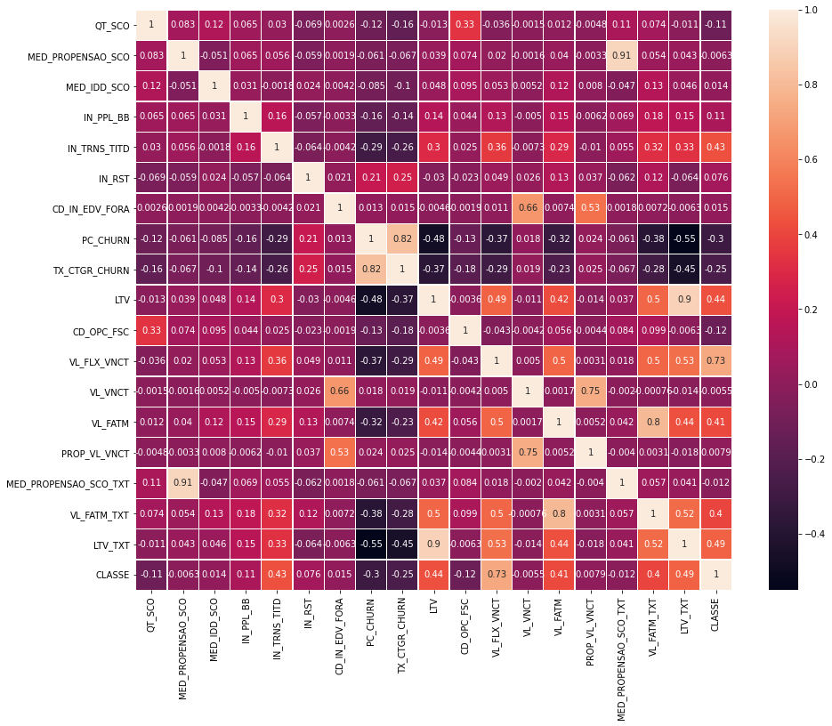

```python
plt.figure(figsize = (15,12))
sns.heatmap(dados_clean.drop(columns=['CD_CLI_PJ']).corr('kendall'), annot=True,linewidths=.3)
plt.show()
```

```python
dados_clean.reset_index(drop=True,inplace = True)
dados_clean.to_csv('dados_clean.csv',index = False)
```

```python
#dados_clean.TX_CLSC_NVL.unique()
```

# Transformação dos dados

- one hot encoding nas colunas que não tem "ordenação(ordinal)"
- label encoder nas colunas que tem "ordenação(ordinal)"

**ONE HOT ENCODER**

```python
# https://scikit-learn.org/stable/modules/generated/sklearn.preprocessing.OneHotEncoder.html
colunas_categoricas = ['SG_UF','CD_GER_SCO','NM_SGM_BB','RFV']
enc = OneHotEncoder(handle_unknown='ignore')
X = dados_clean[colunas_categoricas] #[['Male', 1], ['Female', 3], ['Female', 2]]
enc.fit(X)

import joblib as jb
jb.dump({'one_enc': enc},'one_enc.joblib')
```

```
['one_enc.joblib']
```

```python
dados_ohe = ( pd.DataFrame(enc.transform(dados_clean[colunas_categoricas])
                           .toarray(),columns = enc.get_feature_names() ) ) #['' for i in range(len(colunas_categoricas))])) ) #
#dados_ohe.head(20)
```

```python
#dados_ohe.head()
```

**LABEL ENCODER**

"""x = dados_clean.FXA_LTV le_FXA_LTV = preprocessing.LabelEncoder() le_FXA_LTV.fit(x) dados_clean['le_FXA_LTV'] = le_FXA_LTV.transform(x) x = dados_clean.RFV le_RFV = preprocessing.LabelEncoder() le_RFV.fit(x) dados_clean['le_RFV'] = le_RFV.transform(x) x = dados_clean.TX_MED_PDRD le_TX_MED_PDRD = preprocessing.LabelEncoder() le_TX_MED_PDRD.fit(x) dados_clean['le_TX_MED_PDRD'] = le_TX_MED_PDRD.transform(x) """ x = dados_clean.NM_SGM_BB le_NM_SGM_BB = preprocessing.LabelEncoder() le_NM_SGM_BB.fit(x) dados_clean['le_NM_SGM_BB'] = le_NM_SGM_BB.transform(x)

```python
dados_clean = transf_dados(dados_clean)
```

```
Preparação dos Dados
```

plt.figure(figsize = (15,7)) sns.heatmap(dados_clean.drop(columns=['CD_CLI_PJ']).corr('spearman'), annot=True,linewidths=.3) plt.show()

**Análises CORRELAÇAO:**

```python
print("Proporção de valores NA nas colunas")
dados_clean.isnull().sum() / len(dados_clean) * 100
```

```
Proporção de valores NA nas colunas
```

```
CD_CLI_PJ                0.000000
NM_CLI                   0.000000
SG_UF                    0.000585
QT_SCO                   0.000000
MED_PROPENSAO_SCO        0.000000
MED_IDD_SCO              0.000000
CD_GER_SCO               0.000000
IN_PPL_BB                0.000000
IN_TRNS_TITD             0.000000
IN_RST                   0.000000
CD_IN_EDV_FORA           0.000000
PC_CHURN                 0.000000
TX_CTGR_CHURN            0.000000
LTV                      0.000000
FXA_LTV                  0.000000
RFV                      0.000000
NM_SGM_BB                0.000000
TX_MED_PDRD              0.000000
CD_OPC_FSC               0.000000
VL_FLX_VNCT              0.000000
VL_VNCT                  0.000000
VL_FATM                  0.000000
PROP_VL_VNCT             0.000000
MED_PROPENSAO_SCO_TXT    0.000000
VL_FATM_TXT              0.000000
LTV_TXT                  0.000000
CLASSE                   0.000000
le_FXA_LTV               0.000000
le_RFV                   0.000000
le_TX_MED_PDRD           0.000000
le_CD_GER_SCO            0.000000
le_NM_SGM_BB             0.000000
dtype: float64
```

```python
dados_clean.reset_index(drop=True,inplace=True)
dados_ohe.reset_index(drop=True,inplace=True)
```

```python
dados_clean.shape, dados_ohe.shape
```

```
((170971, 32), (170971, 44))
```

```python
#enc.get_feature_names(['','','','',''])
colunas_categoricas.extend(['FXA_LTV','RFV','NM_SGM_BB','TX_MED_PDRD'])
dados_finais_ohe = pd.concat([dados_clean.drop(columns = colunas_categoricas), dados_ohe],axis = 1)
```

```python
dados_finais_ohe.to_csv('dados_finais_ohe.csv',index = False)
#dados_numericos.to_csv('dados_numericos.csv', index = False)
```